# Chapter3.rmd

2022-11-21

# Logistic regression

## Diary

This week I learned more about logistic regression. This is probably one of the most useful parts of the course for me since I am going to use these methods on my seed bank germination data. Thus, I will likely return to these exercises and methods many times in the near future since this time I couldn’t use as much time on these exercises as I would have wanted. This week I did not have any problems with committing or pushing, yay!

## Reading the data and exploring the structure

```r
getwd()
```

```
## [1] "/home/local/pielaura/Documents/zasemaemulaattori/Documents/kurssit/Introduction_to_open_data_science/excerices_1/IODS-project"
```

```r
setwd("/home/local/pielaura/Documents/zasemaemulaattori/Documents/kurssit/Introduction_to_open_data_science/excerices_1/IODS-project/data")
studentalc <- read.csv("alc.csv", sep = ",")
```

## The names of the variables and a brief description of the data

```r
colnames(studentalc)
```

```
##  [1] "school"     "sex"        "age"        "address"    "famsize"
##  [6] "Pstatus"    "Medu"       "Fedu"       "Mjob"       "Fjob"
## [11] "reason"     "guardian"   "traveltime" "studytime"  "schoolsup"
## [16] "famsup"     "activities" "nursery"    "higher"     "internet"
## [21] "romantic"   "famrel"     "freetime"   "goout"      "Dalc"
## [26] "Walc"       "health"     "failures"   "paid"       "absences"
## [31] "G1"         "G2"         "G3"         "alc_use"    "high_use"
```

```r
dim(studentalc)
```

```
## [1] 370  35
```

Data consists of questionnaires about alcohol consumption of secondary school students in Portugal. Data has variables concerning grades, demography, social features and school features. Dataset is a combination of two datasets addressing the effect of these variables on mathematics and Portuguese. There are 370 observations and 35 variables,

## Relationship between high and low alcohol consumption on a selection of variables

I am investigating whether age, absence, sex or higher have an effect on whether the student consumes high or low amounts of alcohol.

- Age - student’s age (numeric: from 15 to 22)
- Absence = number of school absences (numeric: from 0 to 93)
- Sex = student’s sex (binary: ‘F’ - female or ‘M’ - male)
- Higher = wants to take higher education (binary: yes or no)

### Hypotheses

- age is not expected to have an effect on the alcohol consumption
- number of school absences is higher when the level of alcohol consumption increases
- males are predicted to have higher alcohol consumption than females.
- students that want to take higher education use less alcohol than students that do not want to do so.

## Data exploration

Firstly let’s look at a bar plot made from each focal variable to see how the data looks like

```r
library(tidyr); library(dplyr); library(ggplot2)
focals <- select(studentalc, age, high_use, absences, sex, higher)
glimpse(focals)
```

```
## Rows: 370
## Columns: 5
## $ age      <int> 18, 17, 15, 15, 16, 16, 16, 17, 15, 15, 15, 15, 15, 15, 15, 1…
## $ high_use <lgl> FALSE, FALSE, TRUE, FALSE, FALSE, FALSE, FALSE, FALSE, FALSE,…
## $ absences <int> 5, 3, 8, 1, 2, 8, 0, 4, 0, 0, 1, 2, 1, 1, 0, 5, 8, 3, 9, 5, 0…
## $ sex      <chr> "F", "F", "F", "F", "F", "M", "M", "F", "M", "M", "F", "F", "…
## $ higher   <chr> "yes", "yes", "yes", "yes", "yes", "yes", "yes", "yes", "yes"…
```

```r
focals$higher <- as.factor(focals$higher)
focals$sex <- as.factor(focals$sex)
gather(focals) %>% glimpse
```

```
## Rows: 1,850
## Columns: 2
## $ key   <chr> "age", "age", "age", "age", "age", "age", "age", "age", "age", "…
## $ value <chr> "18", "17", "15", "15", "16", "16", "16", "17", "15", "15", "15"…
```

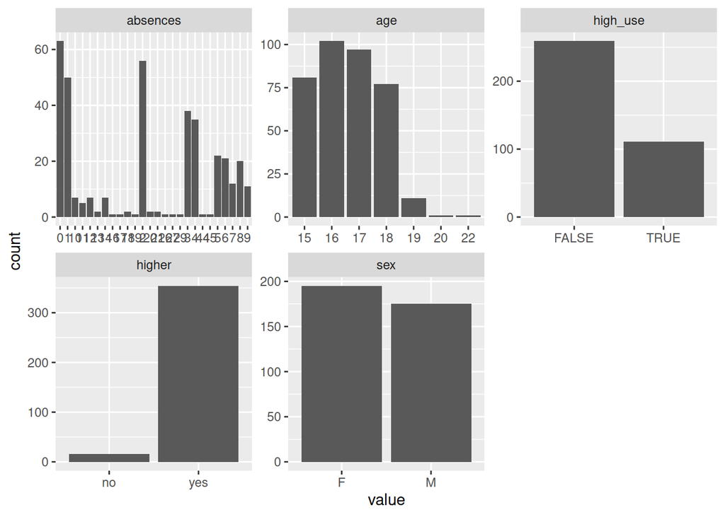

```r
gather(focals) %>% ggplot(aes(value)) + facet_wrap("key", scales = "free") + geom_bar()
```

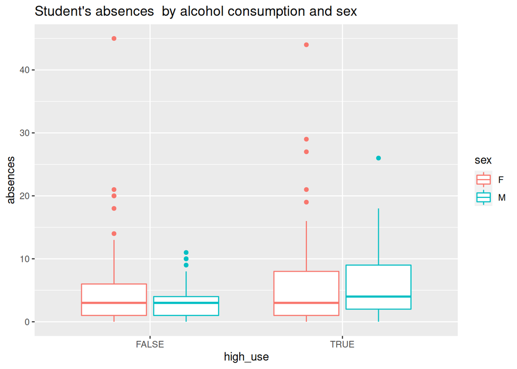

```r
g2 <- ggplot(focals, aes(x = high_use, y = absences, col = sex))
g2 + geom_boxplot() + ylab("absences") + ggtitle("Student's absences  by alcohol consumption and sex")
```

Seems like the students that have more absences quite often use more alcohol. The difference is more clear in males.

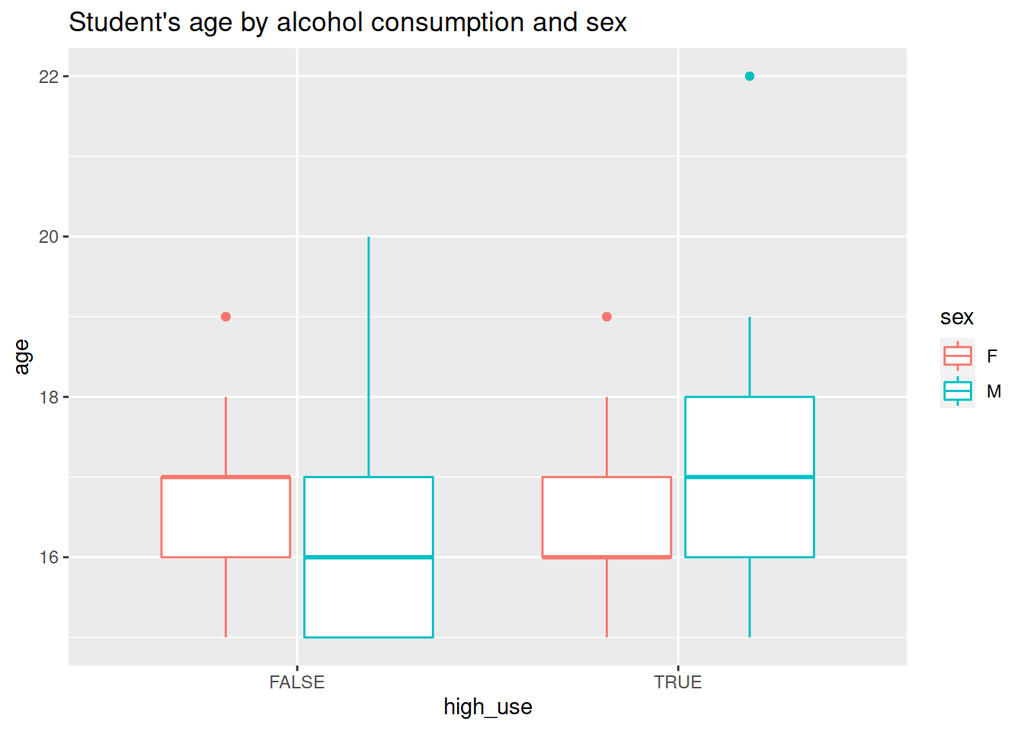

```r
g3 <- ggplot(focals, aes(x = high_use, y = age))

# define the plot as a boxplot and draw it
g3 <- g3 +  geom_boxplot() + ylab("age")

# initialize a plot of high_use and age
g3 <- ggplot(focals, aes(x = high_use, y = age, col = sex))

# define the plot as a box plot and draw it
g3 + geom_boxplot() + ylab("age") + ggtitle("Student's age by alcohol consumption and sex")
```

Older males seem to be using more alcohol than younger ones. For females there is no clear difference except in the average age, which seems to be lower in high alcohol-usage group.

```r
table(high_use = focals$high_use, sex = focals$sex)
```

```
##         sex
## high_use   F   M
##    FALSE 154 105
##    TRUE   41  70
```

```r
table(high_use = focals$high_use, sex = focals$sex, higher = focals$higher)
```

```
## , , higher = no
##
##         sex
## high_use   F   M
##    FALSE   3   4
##    TRUE    0   9
##
## , , higher = yes
##
##         sex
## high_use   F   M
##    FALSE 151 101
##    TRUE   41  61
```

Although there are less males in the data, there are still more males that use alcohol in high amounts. There are very few students that did not plan to go for higher education, thus a meaningful comparison between the differences is questionable.

## Logistic regression

Relationship between the chosen variables and the high/low alcohol consumption. The chosen variables are age, absence, sex, higher

```r
m1 <- glm(high_use ~ age + absences + sex + higher, data = studentalc, family = "binomial")
# summary of the model
summary(m1)
```

```
##
## Call:
## glm(formula = high_use ~ age + absences + sex + higher, family = "binomial",
##     data = studentalc)
##
## Deviance Residuals:
##     Min       1Q   Median       3Q      Max
## -2.5138  -0.8481  -0.6145   1.0774   2.0866
##
## Coefficients:
##             Estimate Std. Error z value Pr(>|z|)
## (Intercept) -3.43120    1.96885  -1.743   0.0814 .
## age          0.13077    0.10550   1.240   0.2151
## absences     0.09319    0.02371   3.930 8.50e-05 ***
## sexM         1.00041    0.24755   4.041 5.32e-05 ***
## higheryes   -0.58694    0.56653  -1.036   0.3002
## ---
## Signif. codes:  0 '***' 0.001 '**' 0.01 '*' 0.05 '.' 0.1 ' ' 1
##
## (Dispersion parameter for binomial family taken to be 1)
##
##     Null deviance: 452.04  on 369  degrees of freedom
## Residual deviance: 412.21  on 365  degrees of freedom
## AIC: 422.21
##
## Number of Fisher Scoring iterations: 4
```

```r
# coefficients
co <- coef(m1)
# coefficients as odds ratios
or <- coef(m1) %>% exp

# confidence intervals
ci <- confint(m1) %>% exp
# odds ratios with confidence intervals
cbind(or, ci)
```

```
##                     or        2.5 %   97.5 %
## (Intercept) 0.03234808 0.0006623013 1.521150
## age         1.13970150 0.9271314963 1.403455
## absences    1.09767298 1.0499229280 1.152322
## sexM        2.71940289 1.6836571895 4.452233
## higheryes   0.55602780 0.1784048183 1.702107
```

## Predictive power of my model

```r
# variables wit a statistical relationship with alcohol consumption
m2 <- glm(high_use ~ absences + sex, data = studentalc, family = "binomial")

# probability of high use (prediction)
probabilities <- predict(m2, type = "response")

# predicted probabilities to the original data
studentalc <- mutate(studentalc, probability = probabilities)

# prediction of high use
studentalc <- mutate(studentalc, prediction = probability > 0.5)

# how it looks like?
select(studentalc, absences, sex, high_use, probability, prediction) %>% tail(10)
```

```
##     absences sex high_use probability prediction
## 361        3   M    FALSE   0.3708919      FALSE
## 362        0   M    FALSE   0.3060791      FALSE
## 363        7   M     TRUE   0.4646683      FALSE
## 364        1   F    FALSE   0.1472516      FALSE
## 365        6   F    FALSE   0.2187809      FALSE
## 366        2   F    FALSE   0.1598138      FALSE
## 367        2   F    FALSE   0.1598138      FALSE
## 368        3   F    FALSE   0.1732299      FALSE
## 369        4   M     TRUE   0.3937240      FALSE
## 370        2   M     TRUE   0.3486225      FALSE
```

```r
# tabulate the target variable versus the predictions
table(high_use = studentalc$high_use, prediction = studentalc$prediction)
```

```
##         prediction
## high_use FALSE TRUE
##    FALSE   251    8
##    TRUE     86   25
```

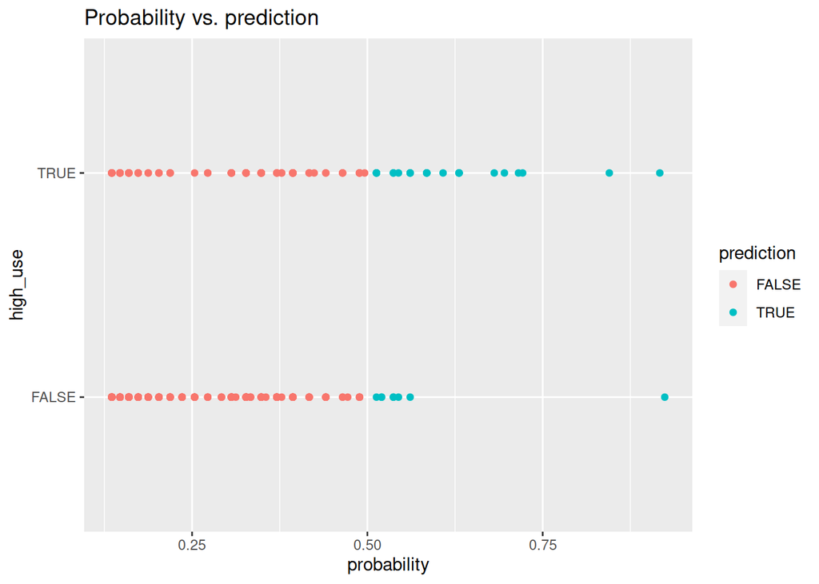

```r
# plot probability vs. prediction
g <- ggplot(studentalc, aes(x = probability, y = high_use, col = prediction))+ggtitle("Probability vs. prediction") + geom_point()
g
```

```r
# tabulate the target variable versus the predictions
table(high_use = studentalc$high_use, prediction = studentalc$prediction) %>% prop.table() %>% addmargins()
```

```
##         prediction
## high_use      FALSE       TRUE        Sum
##    FALSE 0.67837838 0.02162162 0.70000000
##    TRUE  0.23243243 0.06756757 0.30000000
##    Sum   0.91081081 0.08918919 1.00000000
```

Training error (total proportion of inaccurately classified individuals) 0.23243243 + 0.02162162 = 0.254054